# APAN5420_Assignment6_Zhifeng Wang

- **Section 1 Data Preparation**
- **Section 2 Initial observations**
- **Section 3 Features**
- **Section 4 HBOs**
- **Section 5 ECODs**

## Section 1 Data Preparation

```python
import numpy as np
import pandas as pd
import seaborn as sns
import matplotlib.pyplot as plt
```

```python
df = pd.read_csv('purchase_credit_card.csv')
```

```python
# change column names
df.columns = ['Year_Month', 'Agency_Number', 'Agency_Name', 'Cardholder_Last_Name',
      'Cardholder_First_Initial', 'Description', 'Amount', 'Vendor', 'Transaction_Date',
      'Posted_Date', 'Merchant_Category']
```

```python
#Creating separate Year and Month columns for future feature engineering
# Converting Transaction_Date and Posted_date from Python Object data type to datetime
df['Transaction_Date']=pd.to_datetime(df['Transaction_Date'])
df['Posted_Date']=pd.to_datetime(df['Posted_Date'])

df['Year_Month'].dtype
df['Year_Month']=pd.to_datetime(df['Year_Month'], format='%Y%m')
df['Year'] = df['Year_Month'].dt.year
df['Month'] = df['Year_Month'].dt.month
#Creating 'Week_Number' from 'Transaction_Date'
df['Week_Number'] = df['Transaction_Date'].dt.isocalendar().week

#Creating 'Day_of_Week' from 'Transaction_Date'
dayOfWeek={0:'Monday', 1:'Tuesday', 2:'Wednesday', 3:'Thursday', 4:'Friday', 5:'Saturday', 6:'Sunday'}
df['Day_of_Week'] = df['Transaction_Date'].dt.dayofweek.map(dayOfWeek)

df['Day_of_Week'].value_counts()
```

```
Day_of_Week
Wednesday    89644
Thursday     87537
Tuesday      86919
Friday       79917
Monday       61809
Saturday     26307
Sunday       10325
Name: count, dtype: int64
```

## Section 2 Initial observations

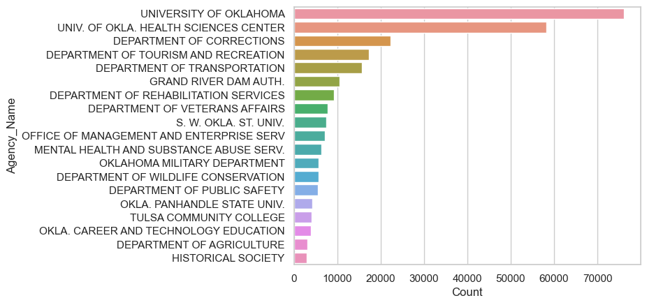

```python
import numpy as np
import plotly
import pandas as pd
import plotly.express as px

# Summarize the count statistics by agency_name in df_count
df_count = df['Agency_Name'].value_counts()
df_count = pd.DataFrame(df_count).reset_index()
df_count.columns = ['Agency_Name','Count']

fig = px.bar(df_count, x='Agency_Name', y='Count', color = 'Agency_Name', width=1000, height=400)
import seaborn as sns
sns.set_theme(style="whitegrid")
sns.barplot(y="Agency_Name", x="Count", data=df_count[1:20])
```

## Section 3 Features

```python
# Create Feature 1: The Ratio to the Median Amount
# Calculate median spending grouped by 'Agency_Name' and 'Merchant_Category'
stat_by_agency = df.groupby(['Agency_Name', 'Merchant_Category'])['Amount'].median().reset_index()
stat_by_agency.columns = ['Agency_Name', 'Merchant_Category', 'Median_amount']
df = pd.merge(df, stat_by_agency, how='left', on=['Agency_Name', 'Merchant_Category'])
df['agency_merchant_median_ratio_amount'] = np.where(
    df['Median_amount'] == 0, 0, df['Amount'] / df['Median_amount']
)
```

```python
# Create Feature 2: The Ratio to the Average Amount
# Calculate average spending grouped by 'Agency_Name' and 'Merchant_Category'
stat_by_agency = df.groupby(['Agency_Name', 'Merchant_Category'])['Amount'].mean().reset_index()
stat_by_agency.columns = ['Agency_Name', 'Merchant_Category', 'AVG_amount']
df = pd.merge(df, stat_by_agency, how='left', on=['Agency_Name', 'Merchant_Category'])
df['agency_merchant_avg_ratio_amount'] = np.where(
    df['AVG_amount'] == 0, 0, df['Amount'] / df['AVG_amount']
)
```

```python
# Feature 3: Ratio to Total Spend (within the group)
total_spend = df.groupby(['Agency_Name', 'Merchant_Category'])['Amount'].sum().reset_index()
total_spend.columns = ['Agency_Name', 'Merchant_Category', 'Total_amount']
df = pd.merge(df, total_spend, how='left', on=['Agency_Name', 'Merchant_Category'])
df['agency_merchant_total_ratio_amount'] = np.where(
    df['Total_amount'] == 0, 0, df['Amount'] / df['Total_amount']
)
```

```python
# Feature 4: Ratio to Vendor Median Spend
vendor_median = df.groupby(['Vendor'])['Amount'].median().reset_index()
vendor_median.columns = ['Vendor', 'Vendor_Median_amount']
df = pd.merge(df, vendor_median, how='left', on='Vendor')
df['vendor_median_ratio_amount'] = np.where(
    df['Vendor_Median_amount'] == 0, 0, df['Amount'] / df['Vendor_Median_amount']
)
```

```python
# Feature 5: Ratio to Day of Week Average Spend
day_avg = df.groupby(['Day_of_Week'])['Amount'].mean().reset_index()
day_avg.columns = ['Day_of_Week', 'Day_Avg_amount']
df = pd.merge(df, day_avg, how='left', on='Day_of_Week')
df['day_of_week_avg_ratio_amount'] = np.where(
    df['Day_Avg_amount'] == 0, 0, df['Amount'] / df['Day_Avg_amount']
)
```

```python
# Feature 6: Ratio to Cardholder Median Spend
cardholder_median = df.groupby(['Cardholder_Last_Name', 'Cardholder_First_Initial'])['Amount'].median().reset_index()
cardholder_median.columns = ['Cardholder_Last_Name', 'Cardholder_First_Initial', 'Cardholder_Median_amount']
df = pd.merge(df, cardholder_median, how='left', on=['Cardholder_Last_Name', 'Cardholder_First_Initial'])
df['cardholder_median_ratio_amount'] = np.where(
    df['Cardholder_Median_amount'] == 0, 0, df['Amount'] / df['Cardholder_Median_amount']
)
```

```python
# Feature 7: Ratio to Merchant Category Average Spend
merchant_category_avg = df.groupby(['Merchant_Category'])['Amount'].mean().reset_index()
merchant_category_avg.columns = ['Merchant_Category', 'Merchant_Category_Avg_amount']
df = pd.merge(df, merchant_category_avg, how='left', on='Merchant_Category')
df['merchant_category_avg_ratio_amount'] = np.where(
    df['Merchant_Category_Avg_amount'] == 0, 0, df['Amount'] / df['Merchant_Category_Avg_amount']
)
```

```python
# Feature 8: Ratio to Total Spend per Month
monthly_total = df.groupby(['Year', 'Month'])['Amount'].sum().reset_index()
monthly_total.columns = ['Year', 'Month', 'Monthly_Total_amount']
df = pd.merge(df, monthly_total, how='left', on=['Year', 'Month'])
df['monthly_total_ratio_amount'] = np.where(
    df['Monthly_Total_amount'] == 0, 0, df['Amount'] / df['Monthly_Total_amount']
)
```

```python
# Feature 9: Ratio to Vendor Total Spend
vendor_total = df.groupby('Vendor')['Amount'].sum().reset_index()
vendor_total.columns = ['Vendor', 'Vendor_Total_amount']
df = pd.merge(df, vendor_total, how='left', on='Vendor')
df['vendor_total_ratio_amount'] = np.where(
    df['Vendor_Total_amount'] == 0, 0, df['Amount'] / df['Vendor_Total_amount']
)
```

```python
# Feature 10: Ratio to Day of Week Median Spend
day_median = df.groupby('Day_of_Week')['Amount'].median().reset_index()
day_median.columns = ['Day_of_Week', 'Day_Median_amount']
df = pd.merge(df, day_median, how='left', on='Day_of_Week')
df['day_of_week_median_ratio_amount'] = np.where(
    df['Day_Median_amount'] == 0, 0, df['Amount'] / df['Day_Median_amount']
)
```

```python
# Feature 11: Ratio to Weekly Total Spend
weekly_total = df.groupby(['Year', 'Week_Number'])['Amount'].sum().reset_index()
weekly_total.columns = ['Year', 'Week_Number', 'Weekly_Total_amount']
df = pd.merge(df, weekly_total, how='left', on=['Year', 'Week_Number'])
df['weekly_total_ratio_amount'] = np.where(
    df['Weekly_Total_amount'] == 0, 0, df['Amount'] / df['Weekly_Total_amount']
)
```

```python
# Feature 12: Ratio to Monthly Agency Average Spend
monthly_agency_avg = df.groupby(['Year', 'Month', 'Agency_Name'])['Amount'].mean().reset_index()
monthly_agency_avg.columns = ['Year', 'Month', 'Agency_Name', 'Monthly_Agency_Avg_amount']
df = pd.merge(df, monthly_agency_avg, how='left', on=['Year', 'Month', 'Agency_Name'])
df['monthly_agency_avg_ratio_amount'] = np.where(
    df['Monthly_Agency_Avg_amount'] == 0, 0, df['Amount'] / df['Monthly_Agency_Avg_amount']
)
```

```python
# Feature 13: Ratio to Monthly Median Spend per Merchant Category
merchant_monthly_median = df.groupby(['Year', 'Month', 'Merchant_Category'])['Amount'].median().reset_index()
merchant_monthly_median.columns = ['Year', 'Month', 'Merchant_Category', 'Merchant_Category_Monthly_Median']
df = pd.merge(df, merchant_monthly_median, how='left', on=['Year', 'Month', 'Merchant_Category'])
df['merchant_category_monthly_median_ratio'] = np.where(
    df['Merchant_Category_Monthly_Median'] == 0, 0, df['Amount'] / df['Merchant_Category_Monthly_Median']
)
```

```python
# Feature 14: Ratio to Cardholder's Average Spend
cardholder_avg = df.groupby(['Cardholder_Last_Name', 'Cardholder_First_Initial'])['Amount'].mean().reset_index()
cardholder_avg.columns = ['Cardholder_Last_Name', 'Cardholder_First_Initial', 'Cardholder_Avg_amount']
df = pd.merge(df, cardholder_avg, how='left', on=['Cardholder_Last_Name', 'Cardholder_First_Initial'])
df['cardholder_avg_ratio_amount'] = np.where(
    df['Cardholder_Avg_amount'] == 0, 0, df['Amount'] / df['Cardholder_Avg_amount']
)
```

```python
# Feature 15: Ratio to Vendor's Monthly Average Spend
vendor_monthly_avg = df.groupby(['Year', 'Month', 'Vendor'])['Amount'].mean().reset_index()
vendor_monthly_avg.columns = ['Year', 'Month', 'Vendor', 'Vendor_Monthly_Avg_amount']
df = pd.merge(df, vendor_monthly_avg, how='left', on=['Year', 'Month', 'Vendor'])
df['vendor_monthly_avg_ratio_amount'] = np.where(
    df['Vendor_Monthly_Avg_amount'] == 0, 0, df['Amount'] / df['Vendor_Monthly_Avg_amount']
)
```

```python
df.head()
```

|  | Year_Month | Agency_Number | Agency_Name | Cardholder_Last_Name | Cardholder_First_Initial | Description | Amount | Vendor | Transaction_Date | Posted_Date | ... | Weekly_Total_amount | weekly_total_ratio_amount | Monthly_Agency_Avg_amount | monthly_agency_avg_ratio_amount | Merchant_Category_Monthly_Median | merchant_category_monthly_median_ratio | Cardholder_Avg_amount | cardholder_avg_ratio_amount | Vendor_Monthly_Avg_amount | vendor_monthly_avg_ratio_amount |
| --- | --- | --- | --- | --- | --- | --- | --- | --- | --- | --- | --- | --- | --- | --- | --- | --- | --- | --- | --- | --- | --- |
| 0 | 2013-07-01 | 1000 | OKLAHOMA STATE UNIVERSITY | Mason | C | GENERAL PURCHASE | 890.00 | NACAS | 2013-07-30 | 2013-07-31 | ... | 3079393.23 | 0.000289 | 295.959575 | 3.007167 | 241.620 | 3.683470 | 269.899489 | 3.297524 | 783.750000 | 1.135566 |
| 1 | 2013-07-01 | 1000 | OKLAHOMA STATE UNIVERSITY | Mason | C | ROOM CHARGES | 368.96 | SHERATON HOTEL | 2013-07-30 | 2013-07-31 | ... | 3079393.23 | 0.000120 | 295.959575 | 1.246657 | 235.405 | 1.567341 | 269.899489 | 1.367027 | 346.480000 | 1.064881 |
| 2 | 2013-07-01 | 1000 | OKLAHOMA STATE UNIVERSITY | Massey | J | GENERAL PURCHASE | 165.82 | SEARS.COM 9300 | 2013-07-29 | 2013-07-31 | ... | 3079393.23 | 0.000054 | 295.959575 | 0.560279 | 239.940 | 0.691089 | 434.824266 | 0.381349 | 116.889286 | 1.418607 |
| 3 | 2013-07-01 | 1000 | OKLAHOMA STATE UNIVERSITY | Massey | T | GENERAL PURCHASE | 96.39 | WAL-MART #0137 | 2013-07-30 | 2013-07-31 | ... | 3079393.23 | 0.000031 | 295.959575 | 0.325686 | 34.910 | 2.761100 | 364.359929 | 0.264546 | 59.859912 | 1.610260 |
| 4 | 2013-07-01 | 1000 | OKLAHOMA STATE UNIVERSITY | Mauro-Herrera | M | HAMMERMILL COPY PLUS COPY EA | 125.96 | STAPLES DIRECT | 2013-07-30 | 2013-07-31 | ... | 3079393.23 | 0.000041 | 295.959575 | 0.425599 | 75.000 | 1.679467 | 93.818028 | 1.342599 | 157.987083 | 0.797280 |

5 rows × 45 columns

## Section 4 HBOs

#### HBOs which is Histogram-Based Outlier Score), a unsupervised anomaly detection method that can identify outlier scores based on the histogram densities of each features. A 95th percentile threshold which is red dash line is used to identify outliers

```python
#!pip install pyod
```

```python
#pip install combo
```

```python
import numpy as np
import pandas as pd
import matplotlib.pyplot as plt
import seaborn as sns
from pyod.models.hbos import HBOS
from sklearn.preprocessing import StandardScaler
from sklearn.model_selection import train_test_split
```

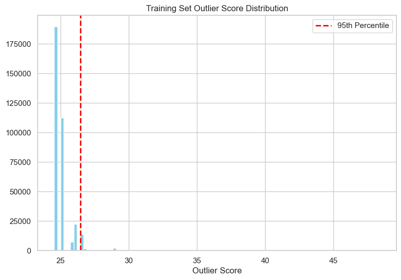

```python
selected_features = [
    'agency_merchant_median_ratio_amount', 'agency_merchant_avg_ratio_amount',
    'agency_merchant_total_ratio_amount', 'vendor_median_ratio_amount',
    'day_of_week_avg_ratio_amount', 'vendor_total_ratio_amount',
    'day_of_week_median_ratio_amount', 'weekly_total_ratio_amount',
    'monthly_agency_avg_ratio_amount', 'merchant_category_monthly_median_ratio',
    'cardholder_avg_ratio_amount', 'vendor_monthly_avg_ratio_amount',
    'cardholder_median_ratio_amount', 'merchant_category_avg_ratio_amount',
    'monthly_total_ratio_amount'
]

X = df[selected_features].dropna()

# Scale the features
scaler = StandardScaler()
X_scaled = scaler.fit_transform(X)

# Split the data
X_train, X_test = train_test_split(X_scaled, test_size=0.2, random_state=42)
X_train, X_test = train_test_split(X, test_size=0.2, random_state=42)

# Train the HBOS model
hbos = HBOS(n_bins=100, contamination=0.1)
hbos.fit(X_train)

# Get the outlier scores
y_train_scores = hbos.decision_function(X_train)
y_test_scores = hbos.decision_function(X_test)

# Define a threshold for anomalies
threshold = np.percentile(y_train_scores, 95)

# Visualize the distribution
plt.figure(figsize=(20, 6))
plt.subplot(1, 2, 1)
plt.hist(y_train_scores,bins=100, color='skyblue')
plt.axvline(threshold, color='red', linestyle='dashed', linewidth=2, label='95th Percentile')
plt.title("Training Set Outlier Score Distribution")
plt.xlabel("Outlier Score")
plt.legend()
```

##### Data points to the right of the red dashed line are flagged as outliers. These are considered to be significantly different from the rest of the dataset and could indicate the abnormal. These outliers may represent unusual spending patterns, transactions that deviate significantly from the regular. Most rare bars as the scores increase (especially above 25-30) indicates that fewer data points are identified as outliers.

```python
threshold = hbos.threshold_
def descriptive_stat_threshold(df,pred_score, threshold):
    # Let's see how many '0's and '1's.
    df = pd.DataFrame(df)
    df.columns = selected_features
    df['Anomaly_Score'] = pred_score
    df['Group'] = np.where(df['Anomaly_Score']< threshold, 'Normal', 'Outlier')

    # Now let's show the summary statistics:
    cnt = df.groupby('Group')['Anomaly_Score'].count().reset_index().rename(columns={'Anomaly_Score':'Count'})
    cnt['Count %'] = (cnt['Count'] / cnt['Count'].sum()) * 100 # The count and count %
    stat = df.groupby('Group').mean().round(2).reset_index() # The avg.
    stat = cnt.merge(stat, left_on='Group',right_on='Group') # Put the count and the avg. together
    return (stat)

descriptive_stat_threshold(X_train,y_train_scores, threshold)
```

|  | Group | Count | Count % | agency_merchant_median_ratio_amount | agency_merchant_avg_ratio_amount | agency_merchant_total_ratio_amount | vendor_median_ratio_amount | day_of_week_avg_ratio_amount | vendor_total_ratio_amount | day_of_week_median_ratio_amount | weekly_total_ratio_amount | monthly_agency_avg_ratio_amount | merchant_category_monthly_median_ratio | cardholder_avg_ratio_amount | vendor_monthly_avg_ratio_amount | cardholder_median_ratio_amount | merchant_category_avg_ratio_amount | monthly_total_ratio_amount | Anomaly_Score |
| --- | --- | --- | --- | --- | --- | --- | --- | --- | --- | --- | --- | --- | --- | --- | --- | --- | --- | --- | --- |
| 0 | Normal | 310128 | 87.615195 | 1.55 | 0.67 | 0.01 | 1.44 | 0.47 | 0.18 | 1.87 | 0.0 | 0.52 | 1.66 | 0.56 | -1.408836e+10 | 1.47 | 0.59 | 0.0 | 24.76 |
| 1 | Outlier | 43838 | 12.384805 | 33.65 | 3.32 | 0.04 | 6.35 | 4.79 | 0.25 | 19.29 | 0.0 | 4.39 | 64.32 | 4.10 | 1.460732e+12 | 1055.07 | 3.90 | 0.0 | 26.71 |

```
Number of outliers in training set: 22091
Number of outliers in test set: 5548
```

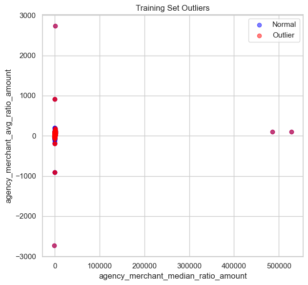

```python
# Identify outliers
train_outliers = y_train_scores > threshold
test_outliers = y_test_scores > threshold

# Print some statistics
print(f"Number of outliers in training set: {sum(train_outliers)}")
print(f"Number of outliers in test set: {sum(test_outliers)}")

# Visualize outliers
plt.figure(figsize=(12, 6))

plt.subplot(1, 2, 1)
plt.scatter(X_train[selected_features[0]], X_train[selected_features[1]], c='blue', label='Normal', alpha=0.5)
plt.scatter(X_train.loc[train_outliers, selected_features[0]],
            X_train.loc[train_outliers, selected_features[1]],
            c='red', label='Outlier', alpha=0.5)
plt.title("Training Set Outliers")
plt.xlabel(selected_features[0])
plt.ylabel(selected_features[1])
plt.legend()

plt.tight_layout()
plt.show()
```

##### Here most points are clustered near the origin, indicating typical behavior. Red points far from the origin show significant deviations, suggesting unusual spending patterns. High values on x-axis or y-axis indicate transaction with unusually high ratios, possibly pointing to errors and frauds.

## Section 5 ECODs

#### ECOD, which is Empirical Cumulative Distribution-based Outlier Detection, is an unsupervised anomaly detection method that identifies outliers based on how data points deviate from the expected distribution. ECOD uses the ECDF(Empirical Cumulative Distribution Function), which describes the probability that a random variable takes a value less than or equal to that certain point. For each feature here, ECOD computes ECDF. And ECOD examines where each data points lies on the ECDF curve.

```python
import numpy as np
import pandas as pd
import matplotlib.pyplot as plt
import seaborn as sns
from pyod.models.ecod import ECOD
from sklearn.preprocessing import StandardScaler
from sklearn.model_selection import train_test_split
```

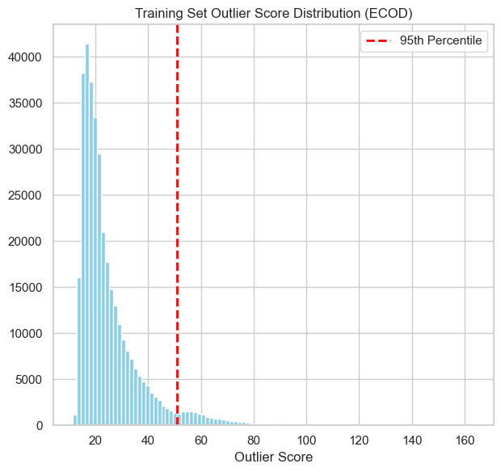

```python
# Train the ECOD model
ecod = ECOD(contamination=0.1)
ecod.fit(X_train)

# Get the outlier scores for both train and test sets
y_train_scores = ecod.decision_function(X_train)
y_test_scores = ecod.decision_function(X_test)

# Define a threshold for anomalies
threshold = np.percentile(y_train_scores, 95)

# Visualize the score distribution
plt.figure(figsize=(12, 6))
plt.subplot(1, 2, 1)
plt.hist(y_train_scores,bins=100,color='skyblue')
plt.axvline(threshold, color='red', linestyle='dashed', linewidth=2, label='95th Percentile')
plt.title("Training Set Outlier Score Distribution (ECOD)")
plt.xlabel("Outlier Score")
plt.legend()

plt.tight_layout()
plt.show()
```

```
Number of outliers in training set: 17699
Number of outliers in test set: 4507
```

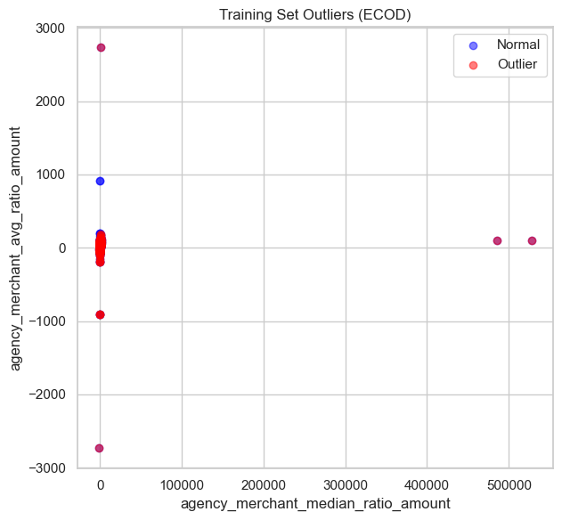

```python
# Identify outliers
train_outliers = y_train_scores > threshold
test_outliers = y_test_scores > threshold

print(f"Number of outliers in training set: {sum(train_outliers)}")
print(f"Number of outliers in test set: {sum(test_outliers)}")

# Visualize outliers
plt.figure(figsize=(12, 6))

plt.subplot(1, 2, 1)
plt.scatter(X_train[selected_features[0]], X_train[selected_features[1]], c='blue', label='Normal', alpha=0.5)
plt.scatter(X_train.loc[train_outliers, selected_features[0]],
            X_train.loc[train_outliers, selected_features[1]],
            c='red', label='Outlier', alpha=0.5)
plt.title("Training Set Outliers (ECOD)")
plt.xlabel(selected_features[0])
plt.ylabel(selected_features[1])
plt.legend()
plt.tight_layout()
plt.show()
```

##### Most normal data points are clustered near the origin, showing consistent. Red points are scattered away from the main cluster, with a few extreme values on X-axis and Y-axis.

```python
threshold = 50
selected_features = [
    'agency_merchant_median_ratio_amount', 'agency_merchant_avg_ratio_amount',
    'agency_merchant_total_ratio_amount', 'vendor_median_ratio_amount',
    'day_of_week_avg_ratio_amount', 'vendor_total_ratio_amount',
    'day_of_week_median_ratio_amount', 'weekly_total_ratio_amount',
    'monthly_agency_avg_ratio_amount', 'merchant_category_monthly_median_ratio',
    'cardholder_avg_ratio_amount', 'vendor_monthly_avg_ratio_amount',
    'cardholder_median_ratio_amount', 'merchant_category_avg_ratio_amount',
    'monthly_total_ratio_amount'
]

# Ensure X_train is a DataFrame with named columns
X_train_df = pd.DataFrame(X_train, columns=selected_features)

# Compute and display the descriptive statistics
stats = descriptive_stat_threshold(X_train_df, y_train_scores, threshold)
stats
```

|  | Group | Count | Count % | agency_merchant_median_ratio_amount | agency_merchant_avg_ratio_amount | agency_merchant_total_ratio_amount | vendor_median_ratio_amount | day_of_week_avg_ratio_amount | vendor_total_ratio_amount | day_of_week_median_ratio_amount | weekly_total_ratio_amount | monthly_agency_avg_ratio_amount | merchant_category_monthly_median_ratio | cardholder_avg_ratio_amount | vendor_monthly_avg_ratio_amount | cardholder_median_ratio_amount | merchant_category_avg_ratio_amount | monthly_total_ratio_amount | Anomaly_Score |
| --- | --- | --- | --- | --- | --- | --- | --- | --- | --- | --- | --- | --- | --- | --- | --- | --- | --- | --- | --- |
| 0 | Normal | 335503 | 94.783962 | 2.03 | 0.89 | 0.02 | 1.71 | 0.68 | 0.20 | 2.71 | 0.0 | 0.78 | 2.18 | 0.91 | 1.297143e+11 | 2.47 | 0.77 | 0.0 | 22.97 |
| 1 | Outlier | 18463 | 5.216038 | 69.00 | 3.00 | -0.00 | 8.21 | 6.94 | 0.07 | 28.06 | 0.0 | 4.99 | 141.08 | 2.57 | 8.745498e+11 | 2484.89 | 5.10 | 0.0 | 63.40 |

##### Here chosing the threshold as 50, which means that any points with an anomaly score above 50 is outlier. Features agency_merchant_median_ratio_amount, vendor_median_ratio_amount, and merchant_category_monthly_median_ratio have outliers much higher values. This indicates that outliers deviate significantly from typical behavior, suggesting that unusual spending, possible fraud in transactions.